# 民主政治 民主政治的未竟之業：回顧與前瞻

師大公領系教授 黃信豪

2021/1

### Topics

**一、回顧：轉型正義**  
**二、前瞻：慎防民主危機**

**指定閱讀**：  
1.吳乃德，2006，「轉型正義和歷史記憶：台灣民主化的未竟之業」，*思想*，2，頁1-34。

2.*獨裁者的進化*，前言。

# 一、回顧：轉型正義

- [最新研究：228事件死亡人數估1304至1512人](https://www.peoplenews.tw/news/f38b3b50-2686-43e6-af04-b86bacb49368)

### （一）什麼是轉型正義

- 轉型正義(transitional justice)：一個國家在進行民主轉型後處理「正義」的工程。
  - 政權變遷後，新民主政府對過去非民主政府違法和不正義行為的彌補，包括清算政府之不義，或是補償舊政府時的政治受害者等。
  - 範圍：1.處置加害者、2.賠償受害者、3.歷史記憶的保存 $\to$ 目的：社會和解，確保過去侵犯人權的情事，未來不再發生(for 民主鞏固)。
- 屬**道德**問題非**法律**問題，更是**政治**問題。
  - Taiwan? 戒嚴時期侵害人權作為…
  - 2016年DPP上台後的作為：不當黨產處理條例/委員會、促轉條例/委員會

### （二）轉型正義的難題

- 民主轉型後，新民主政府應該如何處理過去威權或極權政府對人權的眾多侵犯？ 「積極處理」或者「消極不作為」？ 影響因素：
  - To do：民眾對新政府的期待？下一次選舉？
  - Not to do：
    - 1.考慮軍隊、情治系統的支持？
    - 2.社會分裂？原威權政府的社會支持？ $\to$ 2000年第一次政黨輪替（陳水扁）
  - 其他的影響因素：see[凋零的义人，缺席的正义：转型后的“除垢”为何艰难](http://cnpolitics.org/2017/10/skeletons-in-the-closet/)
    - 3.反對派的歷史負擔？（東歐國家：波蘭、匈牙利、捷克）
    - 4.當下社會經濟條件？當社會經濟發展衰退，先處理轉型正義（社會支持）？南韓的轉型正義：1988年光州事件平反、全斗煥判刑。

### （三）處理轉型正義的不同方式

- 1.**起訴並懲罰加害者**：要追究侵犯人權的政治和道德責任。
  - 難題：界線何在？限於最高領袖（羅馬尼亞、保加利亞、南韓等），還是包括統治所有人員（東德、捷克除垢法）？
    - 執法人員可能沒有選擇？法律界線問題?see [人性的弱點，米爾格拉姆實驗 | 老高與小茉](https://www.youtube.com/watch?v=WNJYh9TgN-Y)
  - 後果與影響：難與原威權政體妥協$\to$民主轉型的路徑重要。
- 2.**刻意遺忘歷史**：菁英達成共識，不追溯過去行為，已換取對民主的支持，如西班牙、烏拉圭的「去記憶」策略。
  - 案例：智利：領導人下台前，以特赦作為交出權力的先決條件。
- 3.**揭露真相，但赦免加害者**：在完整交代加害者罪刑下，換取法律上豁免。 - 案例：南非的真相調查委員會$\to$妥協。
- Q. 支持哪一種？Taiwan又屬於哪一種?

### （四）臺灣轉型正義的不作為、作為

- 1.DPP 1st ruling（含以前）：缺乏歷史真相、正義的轉型$\to$ 不作為。
  - 228事件+白色恐怖：有侵害人權的案件，但無加害者。
    - 李登輝成立228事件研究小組：揭露傷亡事件，不在判別責任。
  - 國民黨黨產、黨職併公職…無處理。
- 2.DPP 2nd ruling （2016～）：作為
  - 不當黨產條例：界定：政黨以違反政黨本質或其他悖於民主法治原則之方式，使自己或其附隨組織取得之財產。
  - 促轉條例： 「開放政治檔案」、「清除威權象徵及保存不義 遺址」、「平復司法不法、還原歷史真相並促進社會和解」，以及「處理不當黨產」（1945年起取得）等四大任務項目。
  - 爭議：法律手段、一體適用？（小英基金會是不是政黨附隨組織？）
- 為何政府處置不同？當前政府的作法的目的？揭露真相還是清算？
- **整體社會對轉型正義相對不關心（除了選舉）**，Why?
  - 1.執政黨帶領的民主轉型過程：民主轉型後各政治勢力的比重？
  - 2.威權體制的經濟表現？
  - 3.壓迫的逐漸減緩。

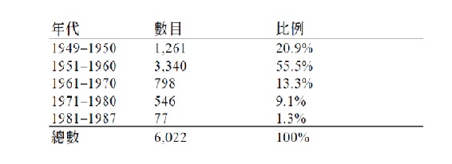

  - 先前的轉型機會(2001～2004)、現在是再一次的轉型良機(2016)？原威權政府的社會支持、當下社會經濟條件…

### （五）小結：客觀面對「轉型正義」問題

- 到底該不該處理？ 如何處理？
  - 1.揭露真相 $\to$ 社會和解、民主鞏固 $\to$ 短痛長多 （回到政策討論）
  - 2.預防未來政府對人權的侵犯。
  - 從分裂的集體社會記憶 $\to$ 共同的社會記憶 $\to$建立政治共同體。
- How?揭露真相>究責（法律上）$\to$ 需要「標的政黨」的「合作」；確保機關的中立性、獨立性。

# 二、前瞻：慎防民主危機

### （一）How democracy die（民主如何死亡）（Levitsky & Ziblatt, 2018）？民主體制終結的三種路徑：

- 1.軍事政變：軍人終止民主政體、接管政治權力$\to$以維護國家安全、民主憲政為由。
  - 第二波回潮（e.g.阿根廷、智利）、巴基斯坦、泰國、土耳其…
- 2.民選領袖明顯破壞民主體制、規則與程序。
  - 第三波（90年代中期）後常見，E.g.:委內瑞拉、俄羅斯…
- 3.無感的民主衰敗（最危險）：民主內涵逐漸被侵蝕 $\to$ 如**選舉公平性**被侵害、**公民權利**逐漸被侵蝕。出現任一跡象，就是「專政」徵兆：
  - (1)用言語或行動拒絕民主制度的遊戲規則（e.g.:改變政府運作）。
  - (2)否認競爭對手的合法性（e.g.:剝奪反對者參政權利、競爭對手描述為顛覆政權、構成國家危機、無證據地暗示對手私通外國…）。
  - (3)容忍或鼓勵支持己方的暴力（對支持自己一方的暴力視而不見）。
  - (4)企圖削減反對者的公民自由（包括媒體在內）。

### （二）影響臺灣未來民主政治的維持與深化的因素？

- 從**理念**、**程序**、**績效**正當性來看
  - 理念：民主公民教育？（老生常談）
  - 程序：無感的民主衰敗？對政治人物（尤其執政者）言行的監督。
  - 績效： 公共政策、治理品質 $\to$近年的8年8800E「前瞻基礎建設計畫」？
    - 人民諮商機制、可責的體制…
  - 外力：中國因素？

# 期末考申論題（事先準備）

如課堂所討論的，東亞國家呈現高度的政體複雜性：「威權穩定」、「民主危機」與「民主鞏固」國家並存。試舉出一些**實際的案例**，討論**儒家傳統文化與價值觀**對東亞國家民主轉型帶來的影響，以及這項因素對這個區域國家的民主治理帶來什麼特色？